# ps5

Linda Wang

2023-02-15

# Load and check data:

#### 1. create a new rmarkdown document with an appropriate title.

```r
# show the work directory
getwd()
```

```
## [1] "/Users/milinkway/Desktop/info201/ps5"
```

The name of this file is **ps5**.

#### 2. Load data. How many rows/columns do we have?

```r
# load the data
data <- read_delim("data/gapminder.csv")
```

The *gapminder* data contains 13055 rows and 25 columns.

#### 3. Print a small sample of data. Does it look OK?

```r
data %>%
  sample_n(3) %>%
  knitr::kable()
```

| iso3 | name | iso2 | region | sub-region | intermediate-region | time | totalPopulation | fertilityRate | lifeExpectancy | childMortality | youthFemaleLiteracy | youthMaleLiteracy | adultLiteracy | GDP_PC | accessElectricity | agriculturalLand | agricultureTractors | cerealProduction | fertilizerHa | co2 | greenhouseGases | co2_PC | pm2.5_35 | battleDeaths |
| --- | --- | --- | --- | --- | --- | --- | --- | --- | --- | --- | --- | --- | --- | --- | --- | --- | --- | --- | --- | --- | --- | --- | --- | --- |
| BIH | Bosnia and Herzegovina | BA | Europe | Southern Europe | NA | 1999 | 3743354 | 1.562 | 74.05000 | 10.3 | NA | NA | NA | 2863.848 | NA | 21050 | NA | 1368792 | 44.21053 | 10377.61 | 15369.3 | 2.77228 | NA | NA |
| SGP | Singapore | SG | Asia | South-eastern Asia | NA | 1972 | 2152400 | 3.040 | 69.04290 | 24.1 | NA | NA | NA | 8332.486 | NA | 110 | NA | NA | 1000.00000 | 22240.35 | NA | 10.33282 | NA | NA |
| ROU | Romania | RO | Europe | Eastern Europe | NA | 2014 | 19908979 | 1.560 | 74.90976 | 9.8 | NA | NA | NA | 9339.275 | 100 | 138300 | NA | 22070736 | 51.51959 | 69489.65 | NA | 3.49037 | 0 | NA |

The data showed *in the table view* looks good, but when it *prints out as a table* it looks a little bit too long.

# Descriptive statistics:

#### 1. How many countries are there in the dataset?

```r
data %>%
  select(iso2, iso3, name) %>%
  summarize(
    num_iso2 = n_distinct(iso2),
    num_iso3 = n_distinct(iso3),
    num_name = n_distinct(name)
  )
```

```
## # A tibble: 1 × 3
##   num_iso2 num_iso3 num_name
##      <int>    <int>    <int>
## 1      249      253      250
```

There are **249** countries in *iso2* column, **253** countries in *iso3* column, **250** countries in *name* column.

#### 2. If you did this correctly, you saw that there are more iso-2 codes than names, and there are even more iso3 -codes. What is going on? Can you find it out?

##### a).Find how many names are there for each iso-2 code. Are there any iso-2 codes that correspond to more than one name? What are these countries?

```r
data %>%
  group_by(iso2) %>%
  summarize(num_name = n_distinct(name),
            country_name = toString(unique(name))) %>%
  filter(num_name > 1)
```

```
## # A tibble: 1 × 3
##   iso2  num_name country_name
##   <chr>    <int> <chr>
## 1 <NA>         2 NA, Namibia
```

##### b). Now repeat the same for name and iso3-code. Are there country names that have more than one iso3-code? What are these countries?

```r
data %>%
  group_by(iso3) %>%
  summarize(num_name = n_distinct(name)) %>%
  filter(num_name > 1)
```

```
## # A tibble: 0 × 2
## # … with 2 variables: iso3 <chr>, num_name <int>
```

There is no iso-3 codes that correspond to more than one name.

#### 3. What is the minimum and maximum year in these data?

```r
x <- min(data$time, na.rm = TRUE)
x
```

```
## [1] 1960
```

```r
y <- max(data$time, na.rm = TRUE)
y
```

```
## [1] 2019
```

The *minimum* year is 1960, and *maximum* year is 2019.

# CO2 emissions:

#### 1. How many missing co2 emissions are there for each year? Analyze both missing CO2 and co2_PC. Which years have most missing data?

```r
data %>%
  group_by(time) %>%
  summarize(
    missing_co2 = sum(is.na(co2)),
    missing_co2_pc = sum(is.na(co2_PC))
  ) %>%
  mutate(total_missing = missing_co2 + missing_co2_pc) %>%
  arrange(desc(total_missing))
```

```
## # A tibble: 61 × 4
##     time missing_co2 missing_co2_pc total_missing
##    <dbl>       <int>          <int>         <int>
##  1  2017         217            217           434
##  2  2018         217            217           434
##  3  2019         217            217           434
##  4  1960          60             60           120
##  5  1961          60             60           120
##  6  1962          58             58           116
##  7  1963          57             57           114
##  8  1964          51             51           102
##  9  1965          51             51           102
## 10  1966          51             51           102
## # … with 51 more rows
```

*Year 2017, 2018, 2019* have the most missing data.

#### 2. Make a plot of total CO2 emissions over time for the U.S, China, and India. Add a few more countries of your choice. Explain what do you see.

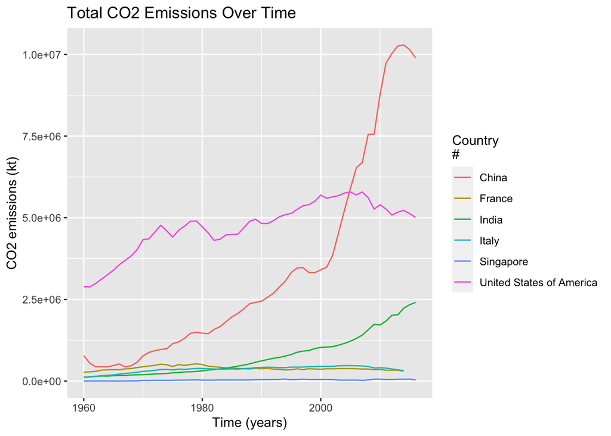

```r
# select the variables that we need for plot
country <- c("United States of America", "China", "India", "France", "Singapore", "Italy")
filtered_data <- data %>%
  filter(name %in% country, !is.na(co2)) %>%
  select(name, time, co2)

filtered_data %>%
  ggplot(aes(x = time, y = co2, col = factor(name))) +
  geom_line() +
  labs(title = "Total CO2 Emissions Over Time",
       x = "Time (years)",
       y = "CO2 emissions (kt)",
       col = "Country\n#")
```

In the plot, **United States of America** got the highest $CO_2$ emissions over the time, when about *2005*, **India** and **China** have a strong increase, **China** has token the highest place. **Italy**, **Singapore**, and **France** are stabled in a low $CO_2$ emissions level.

#### 3. Now let’s analyze the CO2 emissions per capita (co2_PC). Make a similar plot of the same countries. What does this figure suggest?

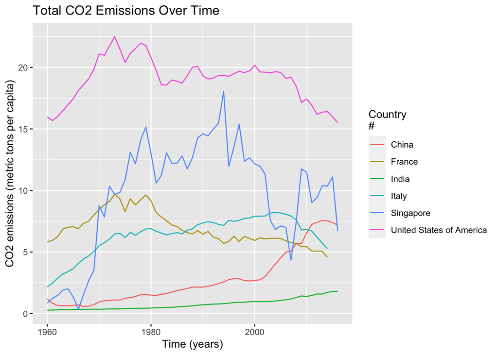

```r
# select the variables that we need for plot
selected_data <- data %>%
  filter(name %in% country, !is.na(co2_PC)) %>%
  select(name, time, co2_PC)

selected_data %>%
  ggplot(aes(x = time, y = co2_PC, col = factor(name))) +
  geom_line() +
  labs(title = "Total CO2 Emissions Over Time",
       x = "Time (years)",
       y = "CO2 emissions (metric tons per capita)",
       col = "Country\n#")
```

#### 4. Compute average CO2 emissions per capita across the continents (assume region is the same as continent). Comment what do you see.

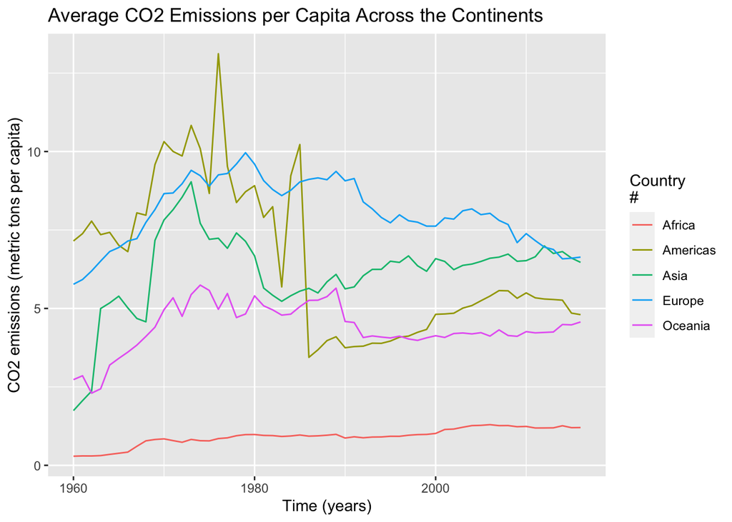

```r
data %>%
  group_by(region, time) %>%
  filter(!is.na(co2_PC), !is.na(region)) %>%
  summarize(avg_co2_PC = mean(co2_PC, na.rm = TRUE), .groups = 'drop') %>%
  ggplot(aes(x = time, y = avg_co2_PC, color = region)) +
  geom_line() +
  labs(title = "Average CO2 Emissions per Capita Across the Continents",
       x = "Time (years)",
       y = "CO2 emissions (metric tons per capita)",
       col = "Country\n#")
```

In this plot, **Africa** has the lowest $CO_2$ emissions, **America** has the highest $CO_2$ emissions before *1985* and decreasing after that. **Europe** has the highest $CO_2$ emissions after *1985*. **Oceania** and **Asian** have a peak between *1960* and *1990* then stabled.

#### 5. Make a barplot where you show the previous results–average CO2 emissions per capita across continents in 1960 and 2016.

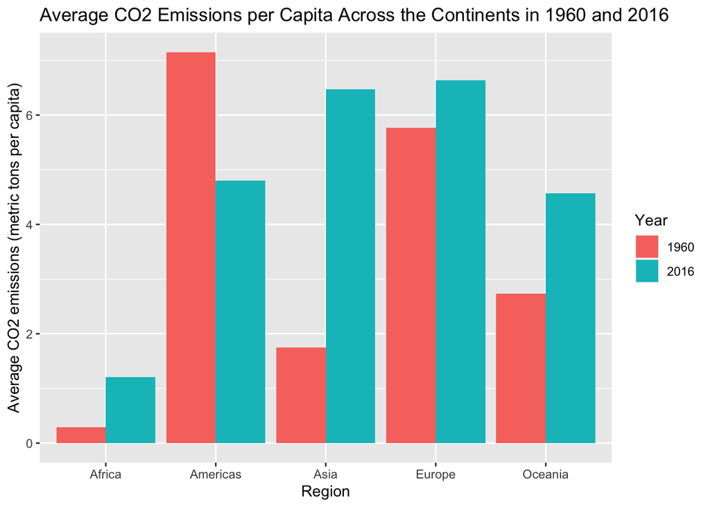

```r
data %>%
  filter(time %in% c(1960, 2016)) %>%
  group_by(region, time) %>%
  filter(!is.na(co2_PC), !is.na(region)) %>%
  summarize(avg_co2_PC = mean(co2_PC, na.rm = TRUE), .groups = 'drop') %>%
  ggplot(aes(x = region, y = avg_co2_PC, fill = factor(time))) +
  geom_col(position = "dodge") +
  labs(title = "Average CO2 Emissions per Capita Across the Continents in 1960 and 2016",
       x = "Region", y = "Average CO2 emissions (metric tons per capita)",
       fill = "Year")
```

#### 6. Which countries are the three largest, and three smallest CO2 emitters (in terms of CO2 per capita) in 2019 for each continent? (Assume region is continent)

```r
data %>%
  filter(time == 2019, !is.na(co2_PC), !is.na(region)) %>%
  group_by(region) %>%
  arrange(desc(co2_PC)) %>%
  summarize(
    largest = list(head(name, n = 3)),
    smallest = list(tail(name, n = 3))
  )
```

```
## # A tibble: 0 × 3
## # … with 3 variables: region <chr>, largest <list>, smallest <list>
```

Since the *co2_PC* values in *2019* are all NA which is missing value, the code can’t return any results.

# GDP per capita:

#### 1. Make a scatterplot of GDP per capita versus life expectancy by country, using data for 1960. Make the point size dependent on the country size, and color those according to the continent. Feel free to adjust the plot in other ways to make it better. Comment what do you see there.

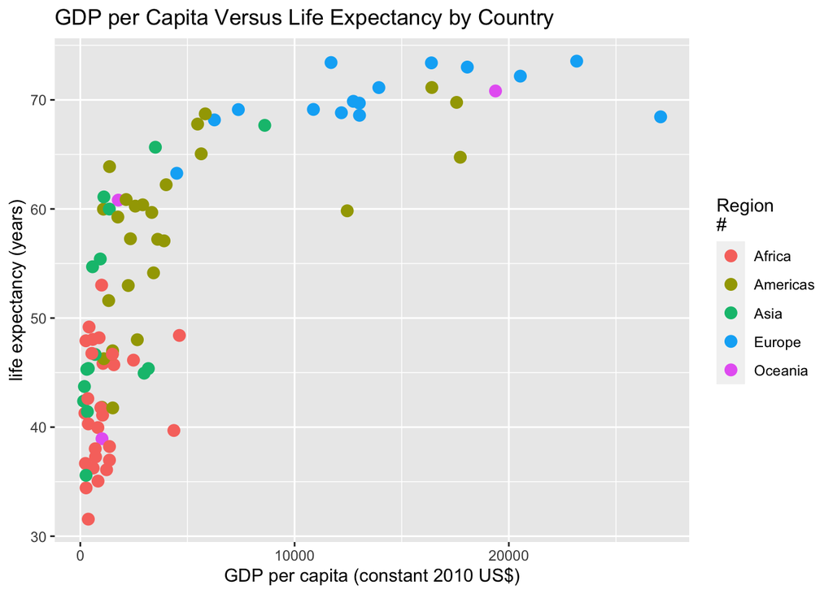

```r
data %>%
  filter(time == 1960, !is.na(GDP_PC),
         !is.na(lifeExpectancy), !is.na(region)) %>%
  ggplot(aes(x = GDP_PC, y = lifeExpectancy, col = factor(region))) +
  geom_point(size = 3) +
  labs(title = "GDP per Capita Versus Life Expectancy by Country",
       x = "GDP per capita (constant 2010 US$)",
       y = "life expectancy (years)",
       col = "Region\n#")
```

From this scatter-plot, we could see that country with *higher* GDP has a *higher* LE. **Europe** has the *highest* GDP and *highest* LE in the plot, which **Africa** has the *lowest* GDP and *lowest* LE. **Asia** was spread more in the *low* GDP and *low* LE area, some are at *high* LE area. **America** was spread more in the *middle* GDP level and *middle-high* LE area, a few are at *low* LE area. **Oceania** were *equally spread* in the plot.

#### 2. Make a similar plot, but this time use 2019 data only

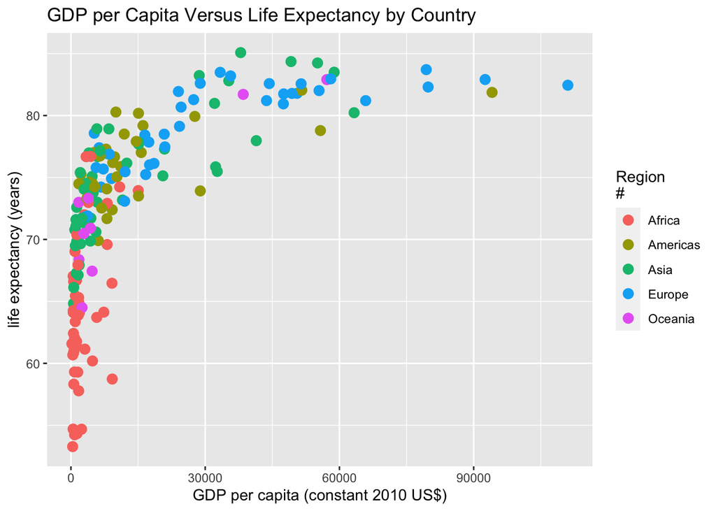

```r
data %>%
  filter(time == 2019, !is.na(GDP_PC),
         !is.na(lifeExpectancy), !is.na(region)) %>%
  ggplot(aes(x = GDP_PC, y = lifeExpectancy, col = factor(region))) +
  geom_point(size = 3) +
  labs(title = "GDP per Capita Versus Life Expectancy by Country",
       x = "GDP per capita (constant 2010 US$)",
       y = "life expectancy (years)",
       col = "Region\n#")
```

#### 3. Compare these two plots and comment what do you see. How has world developed through the last 60 years?

Almost all region were gaining a *higher* level of GDP and LE. There is a **significant growth** of LE level for **Oceania**. **Asia** has both **significant growth** on GDP and LE level. **America** and **Europe** were in the *similar position* to 60 years ago, but still could see *small increasing* of LE level for **America**.

#### 4.Compute the average life expectancy for each continent in 1960 and 2019. Do the results fit with what do you see on the figures?

```r
data %>%
  filter(time %in% c(1960, 2019), !is.na(lifeExpectancy), !is.na(region)) %>%
  group_by(region, time) %>%
  summarize(
    avg_LE = mean(lifeExpectancy)
  )
```

```
## # A tibble: 10 × 3
## # Groups:   region [5]
##    region    time avg_LE
##    <chr>    <dbl>  <dbl>
##  1 Africa    1960   41.5
##  2 Africa    2019   64.1
##  3 Americas  1960   58.6
##  4 Americas  2019   75.8
##  5 Asia      1960   51.6
##  6 Asia      2019   74.6
##  7 Europe    1960   68.3
##  8 Europe    2019   79.4
##  9 Oceania   1960   56.4
## 10 Oceania   2019   73.5
```

Yes, the result fits what I saw in the figure. There is a *increasing* in LE for all region and **Asia** has the *biggest increase*.

#### 5.Compute the average LE growth from 1960-2019 across the continents. Show the results in the order of growth. Explain what do you see.

```r
data %>%
  filter(time %in% c(1960, 2019), !is.na(lifeExpectancy),
         !is.na(region)) %>%
  group_by(region, time) %>%
  summarize(avg_LE = mean(lifeExpectancy, na.rm = TRUE)) %>%
  mutate(prev = lag(avg_LE),
         growth = avg_LE - prev) %>%
  arrange(growth)
```

```
## # A tibble: 10 × 5
## # Groups:   region [5]
##    region    time avg_LE  prev growth
##    <chr>    <dbl>  <dbl> <dbl>  <dbl>
##  1 Europe    2019   79.4  68.3   11.1
##  2 Oceania   2019   73.5  56.4   17.1
##  3 Americas  2019   75.8  58.6   17.2
##  4 Africa    2019   64.1  41.5   22.6
##  5 Asia      2019   74.6  51.6   23.0
##  6 Africa    1960   41.5  NA     NA
##  7 Americas  1960   58.6  NA     NA
##  8 Asia      1960   51.6  NA     NA
##  9 Europe    1960   68.3  NA     NA
## 10 Oceania   1960   56.4  NA     NA
```

After the computation, I see **Asia** has the *highest increase* over all continents, which **Europe** has *least increase* over all continents. Other continents are all *having an increasing* for LE.

#### 6.Show the histogram of GDP per capita for years of 1960 and 2019. Try to put both histograms on the same graph, see how well you can do it!

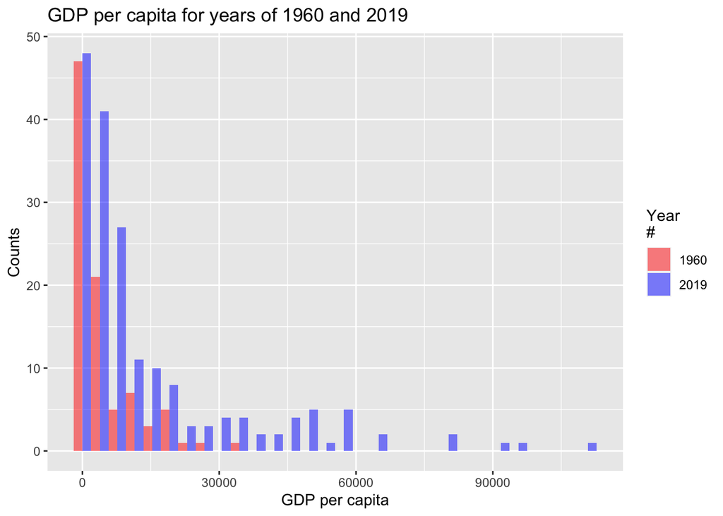

```r
data %>%
  filter(time %in% c(1960, 2019), !is.na(GDP_PC)) %>%
  ggplot(aes(x = GDP_PC, fill = factor(time))) +
  geom_histogram(alpha = 0.5, position = "dodge", bins = 30) +
  labs(title = "GDP per capita for years of 1960 and 2019",
       x = "GDP per capita",
       y = "Counts",
       fill = "Year\n#") +
  scale_fill_manual(values = c("red", "blue"))
```

#### 7.What was the ranking of US in terms of life expectancy in 1960 and in 2019? (When counting from top.)

```r
data %>%
  filter(time %in% c(1960, 2019),
         !is.na(lifeExpectancy), !is.na(name)) %>%
  group_by(time) %>%
  mutate(USA_ranking = rank(desc(lifeExpectancy))) %>%
  filter(name == "United States of America") %>%
  select(time, USA_ranking)
```

```
## # A tibble: 2 × 2
## # Groups:   time [2]
##    time USA_ranking
##   <dbl>       <dbl>
## 1  1960          17
## 2  2019          46
```

#### 8. If you did this correctly, then you noticed that US ranking has been falling quite a bit. But we also have more countries in 2019–what about the relative rank divided by the corresponding number of countries that have LE data in the corresponding year?

```r
data %>%
  filter(time %in% c(1960, 2019),
         !is.na(lifeExpectancy), !is.na(name)) %>%
  group_by(time) %>%
  mutate(ranking = rank(desc(lifeExpectancy)),
         relative_ranking = ranking / n_distinct(name)) %>%
  filter(name == "United States of America") %>%
  select(time, relative_ranking)
```

```
## # A tibble: 2 × 2
## # Groups:   time [2]
##    time relative_ranking
##   <dbl>            <dbl>
## 1  1960           0.0904
## 2  2019           0.235
```

# Final wrap up:

#### tell us how many hours did you spend on this PS

I would like to say 15 hours, I spent a lot of time to get rid of the error.